# 課題9 解答：階層モデルと shrinkage — 経験ベイズと Gibbs サンプラー

計量経済学II

作者

Kei Ikegami

**重要この解答の使い方**

全設問の完全な実行可能コードと、「なぜこう書くか」「どこで間違えやすいか」の解説を付す。各問の末尾に**部分点の目安**を載せた。数値は `seed=23` を前提にした一例で、環境によって小数末尾がわずかに変わりうるが、結論（真値の回収・MSEの順序・EBとGibbsの一致・確率ルールの選抜）は変わらない。

# Part 1：クーポン施策データを自作する（40点）

## 問1（15点）：DGP のパラメータと店舗別データ

```r
N          <- 60
mu_true    <- 2.0
tau2_true  <- 1.0
sigma2     <- 9.0

set.seed(23)

n_i        <- sample(5:100, N, replace = TRUE)      # 店舗規模（不均等）
theta_true <- rnorm(N, mu_true, sqrt(tau2_true))    # 真の店舗効果
s2_i       <- sigma2 / n_i                          # ybar_i の測定分散
ybar       <- rnorm(N, theta_true, sqrt(s2_i))      # no pooling 推定（標本平均）

cat("n_i の範囲:", range(n_i), " 中央値:", median(n_i), "\n")
```

```
n_i の範囲: 7 96  中央値: 52
```

```r
cat("theta_true: 平均", round(mean(theta_true), 3), " 標準偏差", round(sd(theta_true), 3), "\n")
```

```
theta_true: 平均 2.07  標準偏差 0.996
```

**解説**。ポイントは $\bar y_i \sim N(\theta_i,\ \sigma^2/n_i)$ という**標本平均の分布**を使うこと。客ごとの生データ $y_{ij}$ を作ってから平均しても同じだが、標本平均だけ必要なので直接引く方が速い。測定分散が $\sigma^2/n_i$ になるのは、独立な $n_i$ 個の観測の平均の分散が $\sigma^2/n_i$ だから（計量Iの標準誤差の話）。

**ノート部分点の目安（問1）**

- `sample(5:100, ...)` で不均等な $n_i$（5点）
- `rnorm(N, mu_true, sqrt(tau2_true))` で $\theta_i$（**`sqrt` を忘れて分散を標準偏差の位置に入れるミスに注意**）（5点）
- `s2_i = sigma2/n_i` と `ybar ~ N(theta, s2_i)`（5点）

## 問2（15点）：no pooling 推定と真値の散布図、過分散

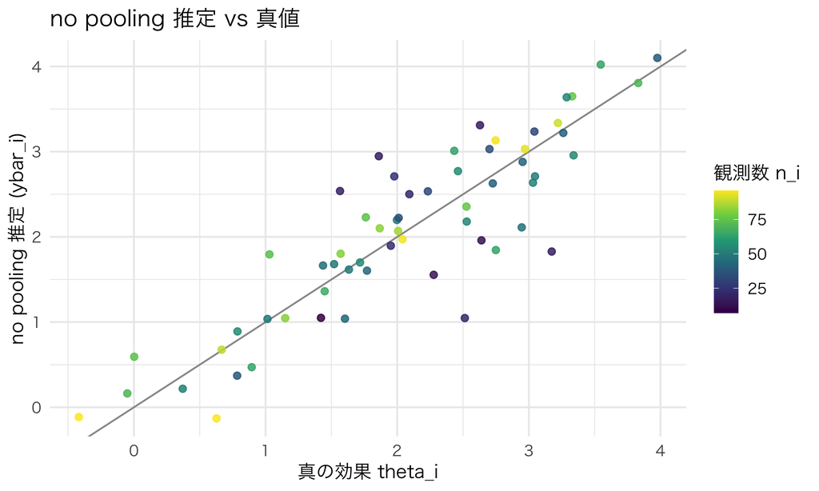

no pooling 推定 vs 真値。小さい店(濃い色)ほど対角線から外れる。

```r
df_np <- data.frame(truth = theta_true, nopool = ybar, n_i = n_i)
ggplot(df_np, aes(truth, nopool, color = n_i)) +
  geom_abline(slope = 1, intercept = 0, color = "grey60") +
  geom_point(size = 2, alpha = 0.85) +
  scale_color_viridis_c(name = "観測数 n_i") +
  labs(title = "no pooling 推定 vs 真値",
       x = "真の効果 theta_i", y = "no pooling 推定 (ybar_i)")
```

```r
cat("真の効果の標準偏差       :", round(sd(theta_true), 3), "\n")
```

```
真の効果の標準偏差       : 0.996
```

```r
cat("no pooling 推定の標準偏差:", round(sd(ybar), 3), "  <- 過分散\n")
```

```
no pooling 推定の標準偏差: 1.053   <- 過分散
```

**解説**。no pooling 推定の標準偏差が真の効果の標準偏差より大きい。理由は $\mathrm{Var}(\bar y_i) = \tau^2 + \sigma^2/n_i > \tau^2$ で、測定ノイズが上乗せされるから。散布図で「濃い色（小さい店）ほど対角線から縦に外れる」のが見えれば、shrinkage の効きどころを正しく理解できている。

**ノート部分点の目安（問2）**

- 散布図＋対角線（`geom_abline`）（6点）
- $n_i$ での色分けまで（＋3点）
- 過分散の確認（`sd(ybar) > sd(theta_true)` を数値で示す）（6点）

## 問3（10点）：測定分散と観測数の関係

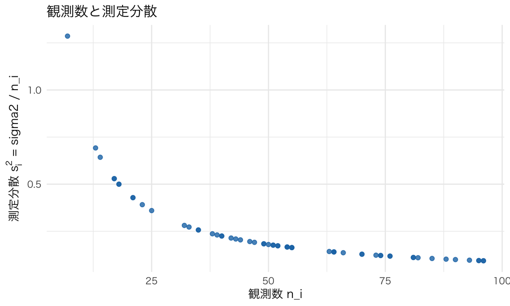

観測数と測定分散。反比例(sigma2/n_i)の曲線。

```r
ggplot(data.frame(n_i = n_i, s2_i = s2_i), aes(n_i, s2_i)) +
  geom_point(color = "#1f77b4", size = 2, alpha = 0.8) +
  labs(title = "観測数と測定分散",
       x = "観測数 n_i", y = expression("測定分散 "*s[i]^2*" = sigma2 / n_i"))
```

**ノート部分点の目安（問3）**

- $s_i^2$ vs $n_i$ の散布図（8点）
- 「反比例＝小さい店ほど分散大」への言及（2点）

# Part 2：経験ベイズ・Gibbs・ターゲティング（60点）

## 問4（12点）：経験ベイズのモーメント法で shrinkage

```r
mu_hat   <- mean(ybar)
tau2_hat <- max(var(ybar) - mean(s2_i), 1e-6)
B_i      <- s2_i / (s2_i + tau2_hat)
eb_est   <- B_i * mu_hat + (1 - B_i) * ybar

cat("mu_hat   =", round(mu_hat, 3),   " （真値", mu_true, "）\n")
```

```
mu_hat   = 2.074  （真値 2 ）
```

```r
cat("tau2_hat =", round(tau2_hat, 3), " （真値", tau2_true, "）\n")
```

```
tau2_hat = 0.872  （真値 1 ）
```

```r
cat("B_i の範囲:", round(range(B_i), 3), "  n_i と B_i の相関:", round(cor(n_i, B_i), 3), "\n")
```

```
B_i の範囲: 0.097 0.596   n_i と B_i の相関: -0.886
```

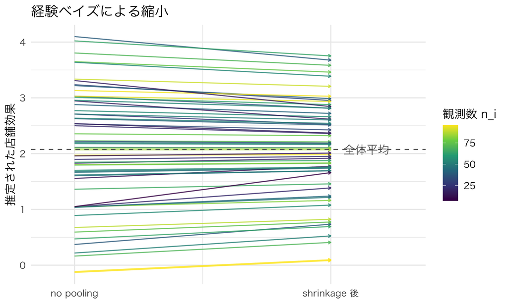

経験ベイズによる縮小。小さい店(濃い色)ほど矢印が長い=全体平均に強く縮む。

```r
df_arrow <- data.frame(nopool = ybar, eb = eb_est, n_i = n_i)
ggplot(df_arrow) +
  geom_segment(aes(x = 1, xend = 2, y = nopool, yend = eb, color = n_i),
               arrow = arrow(length = unit(0.12, "cm")), alpha = 0.8) +
  geom_hline(yintercept = mu_hat, linetype = "dashed", color = "grey40") +
  annotate("text", x = 2.05, y = mu_hat, label = "全体平均", hjust = 0, color = "grey40") +
  scale_x_continuous(breaks = c(1, 2), labels = c("no pooling", "shrinkage 後"), limits = c(0.9, 2.3)) +
  scale_color_viridis_c(name = "観測数 n_i") +
  labs(title = "経験ベイズによる縮小", x = NULL, y = "推定された店舗効果")
```

**ノート部分点の目安（問4）**

- `mu_hat = mean(ybar)`（2点）
- `tau2_hat = max(var(ybar) - mean(s2_i), 1e-6)`（**モーメント法の核。ここが書ければ大きい**）（4点）
- `B_i` と `eb_est` の縮小公式（3点）
- 矢印プロット（3点）

## 問5（10点）：MSE 比較表とモンテカルロ

```r
mse <- function(est) mean((est - theta_true)^2)
data.frame(
  method = c("complete pooling", "no pooling", "empirical Bayes"),
  MSE    = round(c(mse(mu_hat), mse(ybar), mse(eb_est)), 4)
) |> kable(caption = "3つの推定量の MSE（seed=23 の1データセット）")
```

3つの推定量の MSE（seed=23 の1データセット）

| method | MSE |
| --- | --- |
| complete pooling | 0.9762 |
| no pooling | 0.2445 |
| empirical Bayes | 0.1870 |

```r
one_rep <- function() {
  n   <- sample(5:100, N, replace = TRUE)
  s2  <- sigma2 / n
  th  <- rnorm(N, mu_true, sqrt(tau2_true))
  y   <- rnorm(N, th, sqrt(s2))
  muh <- mean(y)
  t2h <- max(var(y) - mean(s2), 1e-6)
  B   <- s2 / (s2 + t2h)
  eb  <- B * muh + (1 - B) * y
  c(complete = mean((muh - th)^2), nopool = mean((y - th)^2), eb = mean((eb - th)^2))
}
set.seed(20269)
sim <- replicate(1000, one_rep())
round(rowMeans(sim), 4)
```

```
complete   nopool       eb
  0.9892   0.2886   0.1996
```

```r
cat("EB が no pooling に勝った割合:", round(mean(sim["eb", ] < sim["nopool", ]), 3), "\n")
```

```
EB が no pooling に勝った割合: 0.938
```

**解説**。1データセットでも1000データセットの平均でも、経験ベイズが最小の MSE を保つ。1000回平均は毎回ほぼ同じ値（おおむね complete $\approx 1.0$、no pooling $\approx 0.29$、EB $\approx 0.20$）に落ち着く（単一データセットの値は乱数でこの周りをぶれる）。EB が no pooling に勝つデータセットの割合は9割強。**complete pooling は「異質性を無視」する分だけ大きく損する**（$\tau^2=1$ の店舗差を全部潰すから）が、no pooling より EB が勝つのは「小さい店のノイズを縮めた」効果だ。バイアス-分散トレードオフを店ごとのデータ量で最適化している。

**ノート部分点の目安（問5）**

- MSE 表（complete は全店 `mu_hat` で計算）（4点）
- EB が最小であることの確認（2点）
- モンテカルロで平均的優位を示す（4点）

## 問6（20点）：Gibbs サンプラーの実装

```r
gibbs_hier <- function(ybar, n_i, sigma2, n_draws = 2000, burn = 500,
                       mu0 = 0, kappa2 = 1e6, a0 = 0.01, b0 = 0.01) {
  N     <- length(ybar)
  theta <- ybar
  mu    <- mean(ybar)
  tau2  <- max(var(ybar), 0.1)
  keep_theta <- matrix(0, n_draws, N)
  keep_mu    <- numeric(n_draws)
  keep_tau2  <- numeric(n_draws)
  for (it in 1:(n_draws + burn)) {
    # (1) theta_i：精度加重平均（データ n_i/sigma2 と prior 1/tau2）
    v_i   <- 1 / (n_i / sigma2 + 1 / tau2)
    m_i   <- v_i * (n_i * ybar / sigma2 + mu / tau2)
    theta <- rnorm(N, m_i, sqrt(v_i))
    # (2) mu：theta たちを tau2 のノイズで見た N 個の観測とみなす
    prec  <- N / tau2 + 1 / kappa2
    mean_ <- (sum(theta) / tau2 + mu0 / kappa2) / prec
    mu    <- rnorm(1, mean_, sqrt(1 / prec))
    # (3) tau2：逆ガンマ = 1/ガンマ（rate に注意）
    shape <- a0 + N / 2
    rate  <- b0 + 0.5 * sum((theta - mu)^2)
    tau2  <- 1 / rgamma(1, shape = shape, rate = rate)
    if (it > burn) {
      k <- it - burn
      keep_theta[k, ] <- theta
      keep_mu[k]      <- mu
      keep_tau2[k]    <- tau2
    }
  }
  list(theta = keep_theta, mu = keep_mu, tau2 = keep_tau2)
}

set.seed(23)
fit <- gibbs_hier(ybar, n_i, sigma2, n_draws = 2000, burn = 500)

cat("Gibbs 事後平均: mu =", round(mean(fit$mu), 3),
    " tau2 =", round(mean(fit$tau2), 3), "\n")
```

```
Gibbs 事後平均: mu = 2.07  tau2 = 1.015
```

```r
cat("（経験ベイズ: mu =", round(mu_hat, 3), " tau2 =", round(tau2_hat, 3), "）\n")
```

```
（経験ベイズ: mu = 2.074  tau2 = 0.872 ）
```

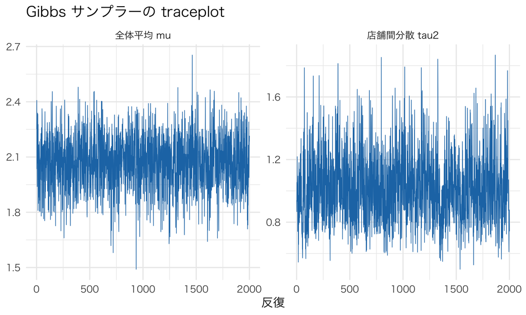

mu と tau2 の traceplot。横ばいの帯に収束していればOK。

```r
df_trace <- data.frame(iter = seq_along(fit$mu), mu = fit$mu, tau2 = fit$tau2) |>
  pivot_longer(c(mu, tau2), names_to = "param", values_to = "value")
ggplot(df_trace, aes(iter, value)) +
  geom_line(color = "#1f77b4", linewidth = 0.3) +
  facet_wrap(~param, scales = "free_y",
             labeller = as_labeller(c(mu = "全体平均 mu", tau2 = "店舗間分散 tau2"))) +
  labs(title = "Gibbs サンプラーの traceplot", x = "反復", y = NULL)
```

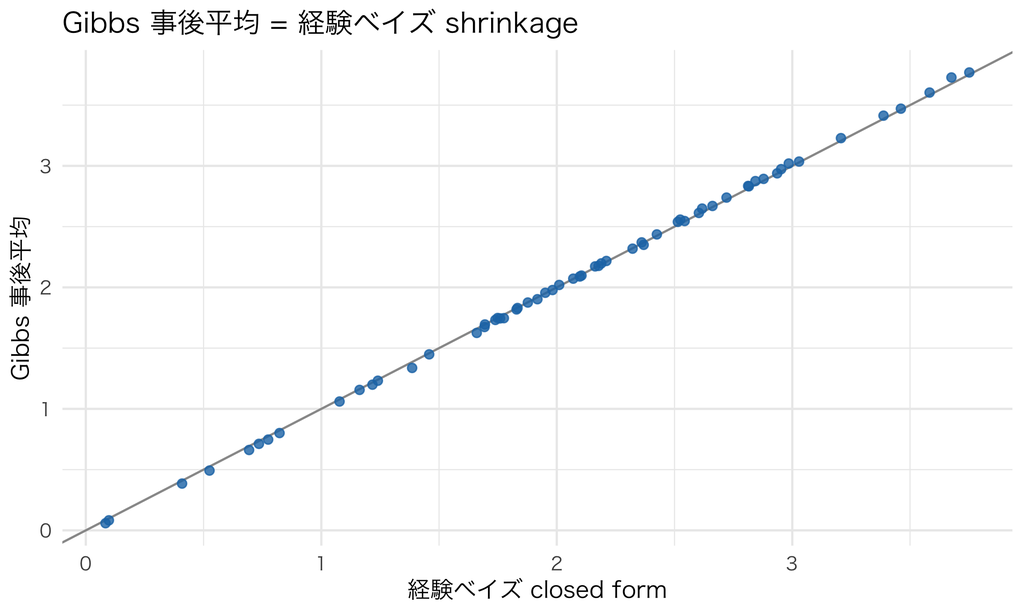

Gibbs の店舗別事後平均 vs 経験ベイズ。対角線上に乗る = 一致。

```r
post_theta_mean <- colMeans(fit$theta)
ggplot(data.frame(eb = eb_est, gibbs = post_theta_mean), aes(eb, gibbs)) +
  geom_abline(slope = 1, intercept = 0, color = "grey60") +
  geom_point(color = "#1f77b4", size = 2, alpha = 0.8) +
  labs(title = "Gibbs 事後平均 = 経験ベイズ shrinkage",
       x = "経験ベイズ closed form", y = "Gibbs 事後平均")
```

```r
cat("Gibbs事後平均 と EB の相関:", round(cor(post_theta_mean, eb_est), 5), "\n")
```

```
Gibbs事後平均 と EB の相関: 0.99991
```

```r
cat("最大のズレ:", round(max(abs(post_theta_mean - eb_est)), 4), "\n")
```

```
最大のズレ: 0.0518
```

**解説**。3本の完全条件付き分布を「順番に引く」だけ。3つの穴のポイント：

- **`v_i = 1 / (n_i / sigma2 + 1 / tau2)`**：事後精度＝データ精度 $n_i/\sigma^2$ ＋ prior 精度 $1/\tau^2$。**分散でなく精度（分散の逆数）を足す**のが肝。`n_i * sigma2` と書くと精度と分散を取り違えて壊れる。
- **`m_i = v_i * (n_i * ybar / sigma2 + mu / tau2)`**：これは§3の shrinkage 公式と同じ形（精度加重平均）。Gibbs は毎ステップ shrinkage を実行している。
- **`tau2 = 1 / rgamma(1, shape, rate = ...)`**：逆ガンマはガンマの逆数。`rate` を使う（`scale` と混同しない）。

**警告採点で見るべき典型ミス**

1. **精度と分散の取り違え**（`n_i / sigma2` を `n_i * sigma2`）→ 事後が異常に広く／狭くなる。
2. **rgamma の rate/scale 混同、逆数の取り忘れ**（`rgamma` をそのまま $\tau^2$ に）→ traceplot が暴走。
3. **burn-in を保存してしまう**（`if (it > burn)` を忘れる）→ 初期の非定常部分が混入。
4. **`rnorm` に分散を渡す**（`rnorm(N, m_i, v_i)`）→ R の `rnorm` は第3引数が**標準偏差**なので `sqrt(v_i)` が要る。

**ノート部分点の目安（問6）**

- `v_i`（精度の和の逆数）（4点）
- `m_i`（精度加重平均）（4点）
- `mu` のサンプリング（3点）
- `tau2` の逆ガンマサンプリング（`1/rgamma(..., rate=...)`）（4点）
- traceplot（2点）
- Gibbs 事後平均 = EB の一致確認（3点）

## 問7（10点）：事後確率ベースのターゲティング

```r
c_thresh <- 3.0
prob_gt  <- colMeans(fit$theta > c_thresh)
sel_prob <- which(prob_gt >= 0.80)
top10_np <- order(ybar, decreasing = TRUE)[1:10]

cat("確率ルール P(theta>3.0)>=0.8 の店数:", length(sel_prob), "\n")
```

```
確率ルール P(theta>3.0)>=0.8 の店数: 5
```

```r
cat("no pooling トップ10 のうち確率ルールに落ちた店:",
    length(setdiff(top10_np, sel_prob)), "店\n")
```

```
no pooling トップ10 のうち確率ルールに落ちた店: 5 店
```

```r
dropped <- setdiff(top10_np, sel_prob)
data.frame(
  store = dropped, n_i = n_i[dropped],
  ybar = round(ybar[dropped], 2), post_mean = round(post_theta_mean[dropped], 2),
  prob_gt = round(prob_gt[dropped], 2), truth = round(theta_true[dropped], 2)
) |> arrange(n_i) |> kable(caption = "点推定では上位、確率ルールで落ちた店（n_i の小さい順）")
```

点推定では上位、確率ルールで落ちた店（n_i の小さい順）

| store | n_i | ybar | post_mean | prob_gt | truth |
| --- | --- | --- | --- | --- | --- |
| 43 | 17 | 3.31 | 2.87 | 0.41 | 2.63 |
| 2 | 32 | 3.24 | 2.97 | 0.48 | 3.04 |
| 12 | 40 | 3.22 | 3.02 | 0.52 | 3.26 |
| 16 | 90 | 3.34 | 3.23 | 0.77 | 3.22 |
| 30 | 95 | 3.13 | 3.04 | 0.55 | 2.75 |

```r
# 落ちた店の観測数と全店の観測数の中央値を比べる（前者が小さいはず）
cat("落ちた店の n_i 中央値:", median(n_i[dropped]),
    " / 全店の n_i 中央値:", median(n_i), "\n")
```

```
落ちた店の n_i 中央値: 40  / 全店の n_i 中央値: 52
```

**解説**。閾値 $c=3.0$ は全店平均 $2.0$ より上にあるので、「効果が3.0を超えると確信できる」には点推定が高いだけでなく不確実性が小さい（$n_i$ 大）ことが要る。確率ルールが選ぶのは十数店以下、no pooling トップ10のうち数店が落ちる。落ちた店を $n_i$ の小さい順に並べると、その中央値は全店の中央値より**小さい**はずだ——データが少ないのに $\bar y_i$ がたまたま高く点推定ランキング上位に来た店たちである。とくに、$\bar y_i$ の派手さのわりに**真値 `truth` が控えめ**な（3.0に届いていない）店が混じっていれば、それは noise で上振れした店であり、確率ルールはこの**無駄打ちを自動で回避**している。「効果が高いかもしれない」と「効果が高いと確信できる」の違いを、事後確率が定量化している。（具体的にどの店が落ちるかは乱数列に依存するので、表の数値そのものより「小さい $n_i$ の店が落ちやすい」という傾向を読み取ってほしい。）

**ノート部分点の目安（問7）**

- `prob_gt = colMeans(fit$theta > c_thresh)`（4点）
- 確率ルールと no pooling トップ10 の比較（3点）
- 落ちた店が「小さい $n_i$・上振れ」であることへのコメント（3点）

## 問8（8点）：経営含意（3行）

**解答例**（3行）：

1. 店舗別クーポン効果ダッシュボードの生ランキングをそのまま信じてはいけない。トップ店の多くは真に優秀なのではなく、たまたま上振れした（とくに来店客数の少ない）店であり、翌月には平均に回帰する。
2. 店舗評価・追加投資の判断は、経験ベイズ／階層ベイズで全体平均に縮めた推定に基づくべきで、とりわけ客数の少ない小型店の生の数値は割り引いて解釈する。
3. 「上位10店に投資」のような点推定ランキングでなく、「効果が閾値を超える確率が一定以上の店」という事後確率の基準で選抜すれば、上振れした小型店への無駄打ちを避けつつ、確度の高い店に予算を集中できる。

**ノート部分点の目安（問8）**

- 「生ランキングの危険（平均への回帰）」への言及（3点）
- 「小さい店を全体平均に縮める」への言及（3点）
- 「点推定でなく確率で選抜」への言及（2点）
- 3行程度で数値・分析に基づいていれば満点。抽象論だけなら減点。

**重要総評：この課題で身につくこと**

- **partial pooling / shrinkage** を、DGP自作 → 経験ベイズ → MSE検証 → Gibbs → 意思決定、の一気通貫で自分の手で回した。
- **経験ベイズのモーメント法**（$\hat\tau^2 = \widehat{\mathrm{Var}}(\bar y) - \overline{s_i^2}$）と、**Gibbs の完全条件付き分布**（精度加重平均＋逆ガンマ）が、同じ shrinkage を別ルートで実現することを確認した。
- ベイズの事後分布が、点推定ランキングにはできない「確率での意思決定」を可能にすることを体感した。

次回（第10回）は、この階層構造を購買履歴に適用する。顧客ごとの購買率のガンマ異質性を推定し、CLVを予測する。今日の道具がそのまま効く。